# Linear Discriminant Analysis with MASS::lda

Jesse Connell

11/27/2018

This report provides a simple walkthrough of the LDA features provided by the MASS R package, using a few idealized cases and more of a geometric/vector interpretation than a classifier/machine learning one. Unfinished parts are marked like this.

```r
library(ggplot2)
library(knitr)
library(kableExtra)

# make_data_basic() below uses rnorm() to get random points on a normal
# distribution.  This ensures we'll always see the same "random" number here.
set.seed(0)

# create a very basic data frame of input data for the LDA.
make_data_basic <- function(Nper=1000) {
  # meas 1 tells us nothing useful.
  # meas 2 is somewhat lower for group 1 and higher for group 2
  # meas 3 is somewhat higher for group 1 and lower for group 2
  obs <- data.frame(
    Meas1 = rnorm(n = Nper*2),
    Meas2 = c(rnorm(n = Nper, mean = -1), rnorm(n = Nper, mean = 1)),
    Meas3 = c(rnorm(n = Nper, mean = 1), rnorm(n = Nper, mean = -1)),
    Group = rep(c("Group1","Group2"), each=Nper)
  )
  # we'll have variables that just happen to look like z-scores...
  obs[, 1:3] <- scale(obs[, 1:3])
  obs
}

### some vector math helper functions
dotprod <- function(x, y) sum(x * y)  # dot product
vecmag  <- function(x) sqrt(sum(x^2)) # magnitude
vecnorm <- function(x) x/vecmag(x)    # normalize to unit vector

# histogram for a given measurement, overlaying all groups
hist_grp <- function(obs, measurement, breaks=seq(-5, 5, 0.1), grp="Group", ...) {
  ggplot(obs) +
    geom_histogram(aes_(x = obs[[measurement]],
                        fill = obs[[grp]]),
                   breaks = breaks,
                   position = "identity",
                   alpha = 0.5,
                   ...) +
    labs(x = measurement, y = "Count", fill = "Group")
}

# scatterplot of two measurements, overalying all groups
scatter_grp <- function(obs, x, y, color="Group", ratio=1) {
  ggplot(obs) +
    geom_point(aes_string(x = x, y = y, color = color)) +
    coord_fixed(ratio = ratio)
}

# Wrapper to attach LDA results to a list of objects, starting from an
# observations data frame.
run_lda <- function(data = list()) {
  within(data, {
    # The two main MASS package steps used here: run the LDA, and perform the
    # prediction that provides actual LD-axis values and automatic
    # classification.
    lds <- MASS::lda(formula = Group ~ ., data = observations)
    prediction <- predict(lds)
    # Attach some output columns to the observations data frame for convenience
    observations$Prediction <- prediction$class
    observations$LD1 <- prediction$x[, 1]
    observations$Wrong <- with(observations, Group != Prediction)
    # Make a confusion matrix for every pair of actual group versus predicted
    # group.  The more we have on the diagonal the better!
    confusion <- table(observations$Group, observations$Prediction)
    rownames(confusion) <- paste0("Actual", rownames(confusion))
    colnames(confusion) <- paste0("Predicted", colnames(confusion))
  })
}
```

# LDA Case 1 - A Basic Case

## Prologue

If we have a set of samples in N groups, and M different measurements per sample, what best differentiates the *groups* of samples from one another? (Not just, what view of the measurements best separates the *samples* from one another; then we’d be thinking PCA, not LDA.) Here we have two groups and three continuous numeric measurements that just happen to each have a mean of zero and a standard deviation of one.

```r
observations <- make_data_basic()
```

Here’s a quick summary of how those values are distributed between the two groups:

```r
preview <- do.call(rbind,
                   lapply(split(observations, observations$Group),
                          head,
                          n = 5))[, -4]
k <- kable(preview, row.names = FALSE, digits = 3)
k <- kable_styling(k, full_width = FALSE)
k <- group_rows(k, "Group1", 1, 5)
k <- group_rows(k, "Group2", 6, 10)
k
```

| Meas1 | Meas2 | Meas3 |
| --- | --- | --- |
| **Group1** |  |  |
| 1.263 | -0.433 | 1.253 |
| -0.301 | -0.750 | -0.105 |
| 1.329 | -0.766 | 0.553 |
| 1.273 | -0.980 | -0.024 |
| 0.428 | -0.398 | 0.116 |
| **Group2** |  |  |
| -0.262 | 0.313 | -0.436 |
| 1.832 | 1.071 | -0.390 |
| -0.134 | -0.350 | -1.570 |
| -1.348 | -0.108 | -1.502 |
| -1.430 | -0.037 | -0.013 |

Distribution and standard deviation per measurement, overall:

```r
summary(observations)
```

```
##      Meas1              Meas2               Meas3              Group
##  Min.   :-3.16608   Min.   :-2.984743   Min.   :-2.955401   Group1:1000
##  1st Qu.:-0.69168   1st Qu.:-0.739485   1st Qu.:-0.708648   Group2:1000
##  Median :-0.02527   Median :-0.003601   Median : 0.002067
##  Mean   : 0.00000   Mean   : 0.000000   Mean   : 0.000000
##  3rd Qu.: 0.70951   3rd Qu.: 0.753842   3rd Qu.: 0.717892
##  Max.   : 3.23562   Max.   : 2.746816   Max.   : 2.751528
```

```r
sapply(observations[, 1:3], sd)
```

```
## Meas1 Meas2 Meas3
##     1     1     1
```

And per group:

```r
lapply(split(observations, observations$Group), summary)
```

```
## $Group1
##      Meas1               Meas2             Meas3            Group
##  Min.   :-3.166077   Min.   :-2.9847   Min.   :-1.3463   Group1:1000
##  1st Qu.:-0.677449   1st Qu.:-1.1799   1st Qu.: 0.2248   Group2:   0
##  Median :-0.037963   Median :-0.7025   Median : 0.6940
##  Mean   : 0.004409   Mean   :-0.7089   Mean   : 0.6981
##  3rd Qu.: 0.696940   3rd Qu.:-0.2429   3rd Qu.: 1.1959
##  Max.   : 3.235623   Max.   : 1.4573   Max.   : 2.7515
##
## $Group2
##      Meas1               Meas2             Meas3            Group
##  Min.   :-2.978025   Min.   :-2.0073   Min.   :-2.9554   Group1:   0
##  1st Qu.:-0.701926   1st Qu.: 0.2284   1st Qu.:-1.1684   Group2:1000
##  Median :-0.011328   Median : 0.7060   Median :-0.6780
##  Mean   :-0.004409   Mean   : 0.7089   Mean   :-0.6981
##  3rd Qu.: 0.726396   3rd Qu.: 1.1815   3rd Qu.:-0.2148
##  Max.   : 3.011777   Max.   : 2.7468   Max.   : 1.4210
```

```r
lapply(split(observations, observations$Group), function(chunk) sapply(chunk[, 1:3], sd))
```

```
## $Group1
##     Meas1     Meas2     Meas3
## 0.9824887 0.6995029 0.7157616
##
## $Group2
##     Meas1     Meas2     Meas3
## 1.0176827 0.7110608 0.7162228
```

**Can we find a linear combination of the measurements that gives the best separation between observations in different groups?** (With only two groups we only need a single linear discriminant to distinguish them, too.)

### Single-Measurement View

Thinking most naively, is there a single measurement that divides the groups nicely?

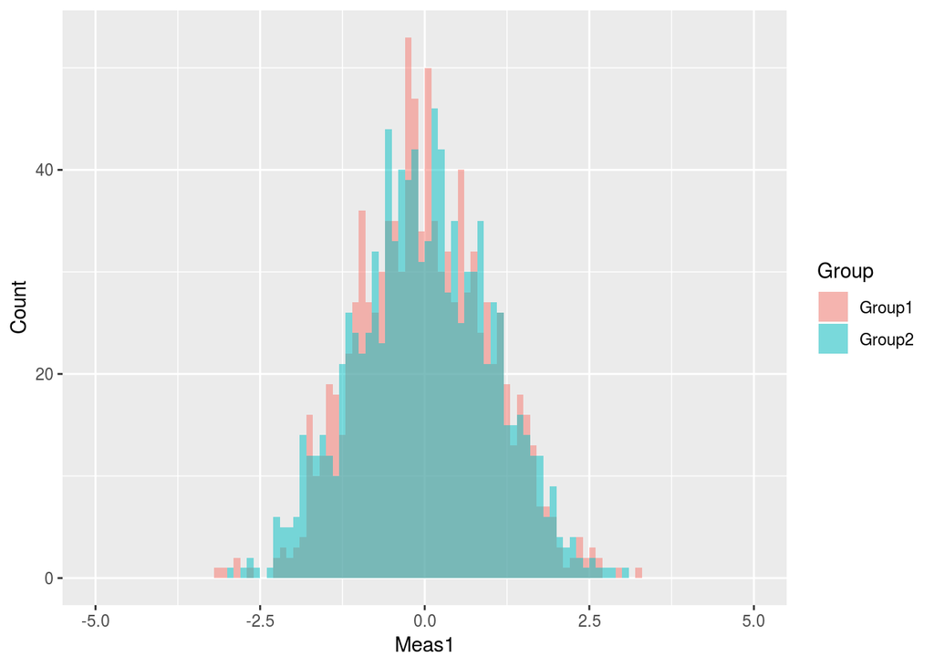

```r
hist_grp(observations, "Meas1")
```

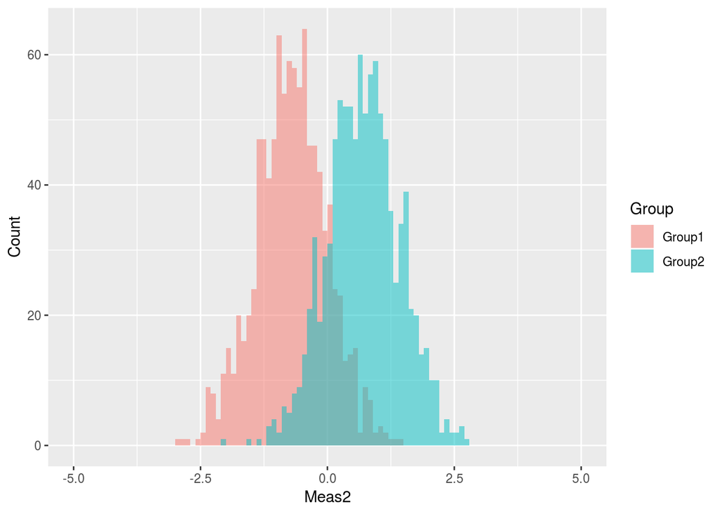

```r
hist_grp(observations, "Meas2")
```

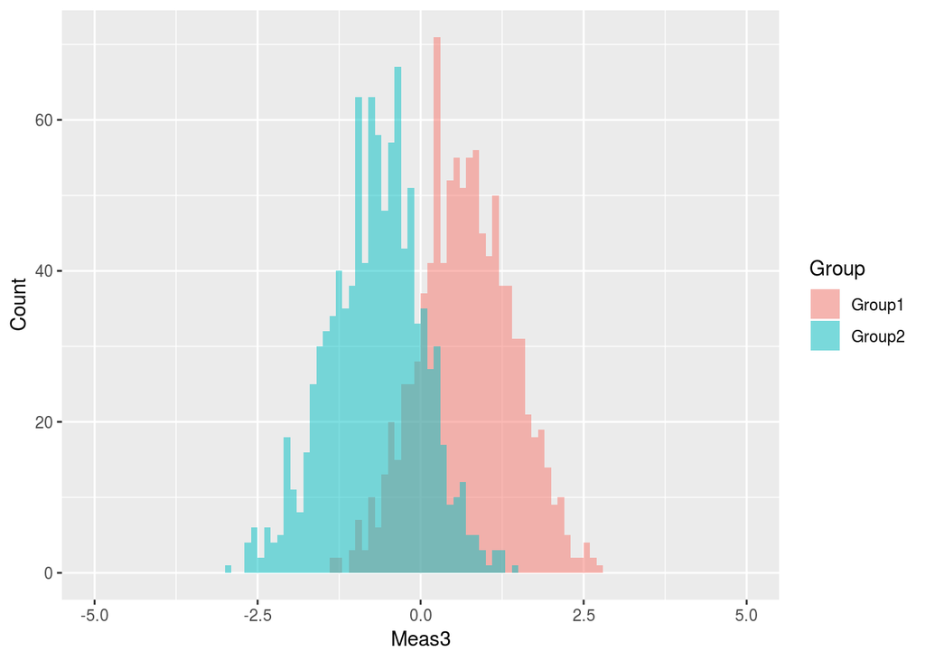

```r
hist_grp(observations, "Meas3")
```

Not really. Meas1 looks indistinguishable between the two groups, and Meas2 and Meas3 provide a hint but not enough to cleanly separate the two groups. Can we see a combination of the measurements that makes it clearer?

### Two-Measurement View

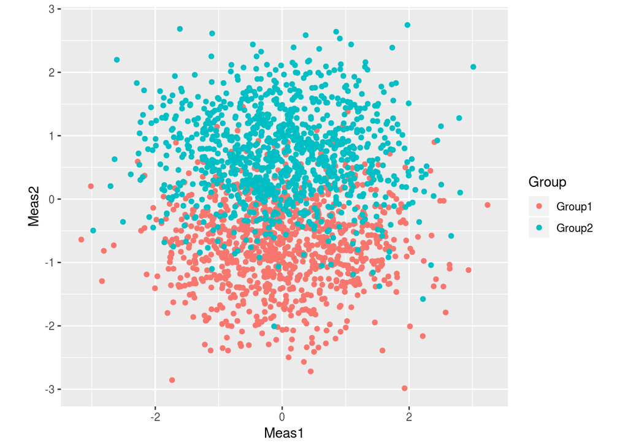

```r
scatter_grp(observations, "Meas1", "Meas2")
```

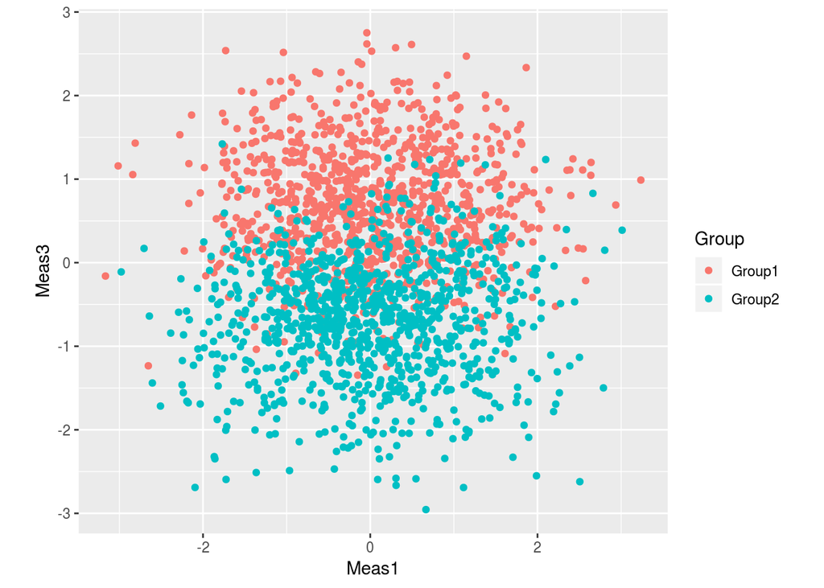

```r
scatter_grp(observations, "Meas1", "Meas3")
```

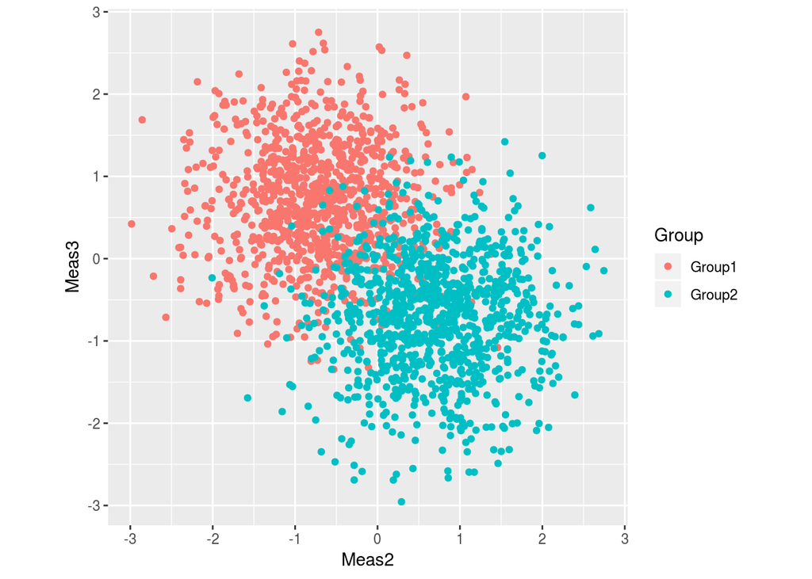

```r
scatter_grp(observations, "Meas2", "Meas3")
```

Well, Meas3 versus Meas2 gives a much better hint at the best separation: a diagonal line through the origin, heading from the lower-left to the upper-right, where points to the upper-left are probably Group1 and those in the lower-right are probably Group2.

### A Linear Discriminant

Or, to think of it as a single vector pointing in the direction of the most separation between the groups, it’s a line running upper-left to lower-right.

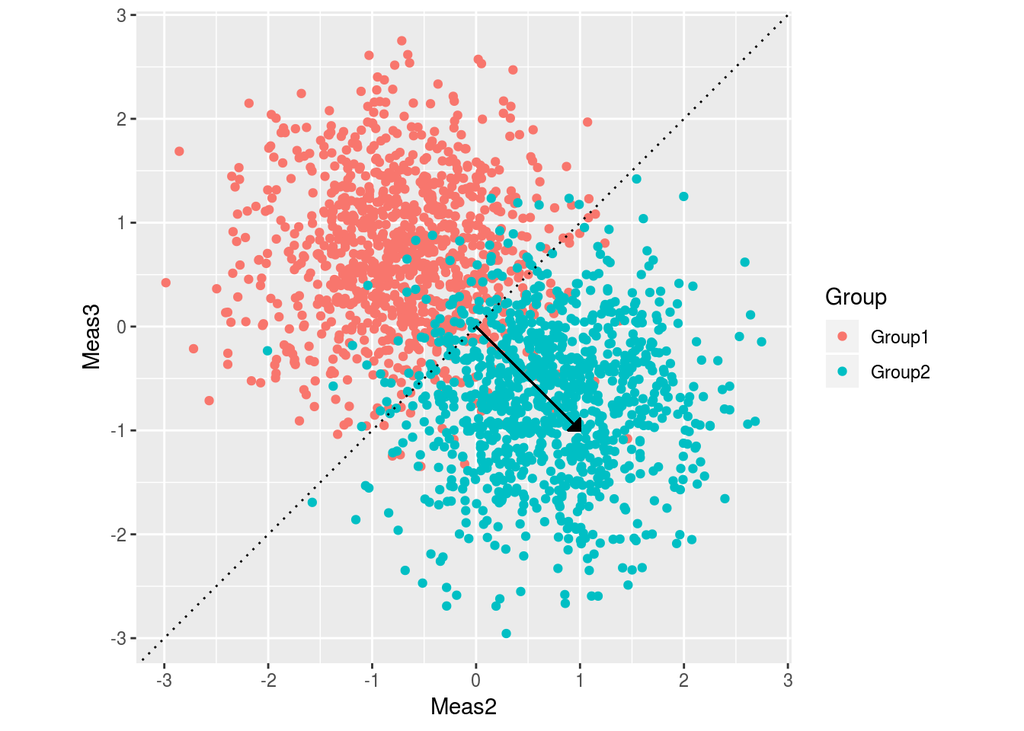

```r
scatter_grp(observations, "Meas2", "Meas3") +
  geom_abline(intercept = 0,
              slope = 1,
              linetype="dotted") +
  geom_segment(x = 0, y = 0, xend = 1, yend = -1,
               arrow = arrow(angle = 45,
                             length = unit(0.2, "cm"),
                             type="closed"))
```

```r
scaling <- data.frame(Component = c(0, 1, -1))
rownames(scaling) <- paste0("Meas", 1:3)
kable_styling(kable(scaling, digits = 3), full_width = FALSE)
```

|  | Component |
| --- | --- |
| Meas1 | 0 |
| Meas2 | 1 |
| Meas3 | -1 |

We can define a new axis (“LD”) as a linear combination of the original three measurements, multiplying each observation by the scaling values, component-wise along the measurements, and summing (i.e., a vector dot product, when we only have one scaling vector).

```r
ld <- apply(observations[, 1:3], 1, dotprod, y = scaling$Component)
ld <- data.frame(LD = ld,
           Group = observations$Group)
```

We have three measurements total, so LD is a vector perpendicular to a plane (or the dashed line above, where we’re ignoring Meas1) diving Group1 from Group2. If we had more measurements, LD would be a vector with more components, but still basically an arrow pointing away from one group and toward another.

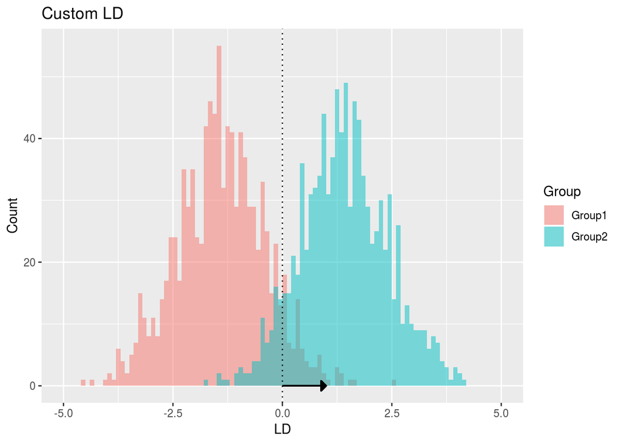

```r
hist_grp(ld, "LD") +
  ggtitle("Custom LD") +
  geom_vline(xintercept = 0,
             linetype="dotted") +
  geom_segment(x = 0, y = 0, xend = 1, yend = 0,
               arrow = arrow(angle = 45,
                             length = unit(0.2, "cm"),
                             type="closed"))
```

This new number gives better separation between the groups than any of the individual measurements. Note that measurements that provide more useful information on separating the groups have a larger component of this new vector, while measurements that do little to distinguish the groups have a component near zero (as Meas1 does here). **But note that in order to handle a measurement that has much larger values than another measurement but the same effect size on the group separation, we’d need a *smaller* vector component for that “larger” measurement. This must be taken into account when comparing the vector components between measurements.** See LDA Case 2 below for more on that.

Most of the points in a given group are on one side or the other of the origin (in this particular case!) along LD, and we can classify observations fairly reliably by that fact alone:

```r
# Here we're banking on the fact that everything's centered on the origin.  See
# case 5 below for a situation where it's not.
ld$Prediction <- c("Group1", "Group2")[(ld$LD >= 0) + 1]
my_confusion <- as.data.frame(table(ld[, 2:3]))
colnames(my_confusion) <- c("Group", "Prediction", "Freq")
kable_styling(kable(my_confusion), full_width = FALSE)
```

| Group | Prediction | Freq |
| --- | --- | --- |
| Group1 | Group1 | 923 |
| Group2 | Group1 | 79 |
| Group1 | Group2 | 77 |
| Group2 | Group2 | 921 |

## Where LDA Comes In

LDA can find that best direction for us automatically, for arbitrary numbers of groups and dimensions, and can take into account scaling/centering issues and the separation of groups along the new axis/axes.

```r
lds <- MASS::lda(formula = Group ~ . , data = observations)
```

### Return Value

The returned object is of class lda, but behaves like a regular list of these things:

#### prior

```
0.5, 0.5
```

We didn’t specify the prior probability that a given sample would be in a particular group, and we gave equal proportions of each here, so it defaulted to that.

#### counts

```
1000, 1000
```

Just numbers of samples per group.

#### means

|  | Meas1 | Meas2 | Meas3 |
| --- | --- | --- | --- |
| Group1 | 0.0044088 | -0.7089016 | 0.6981173 |
| Group2 | -0.0044088 | 0.7089016 | -0.6981173 |

Just the means per measurement per group.

#### scaling

|  | LD1 |
| --- | --- |
| Meas1 | 0.019 |
| Meas2 | 1.025 |
| Meas3 | -0.981 |

**Hey look, that’s the same vector in measurement-space we noticed before!** More on this later.

#### lev

```
Group1, Group2
```

Dunno, the `?MASS::lda` text doesn’t mention it, but it looks like it’s just the grouping values it saw.

#### svd

```
63.1287689
```

Ratios (here, just ratio singular) of between-group and within-group standard deviations for the LD variables (here, just variable singular). The standard deviation in LD1 value is much higher between the two groups than within them.

#### N

```
2000
```

Just how many observations there were total.

#### call

```
lda(formula = Group ~ ., data = observations)
```

The function as we called it.

#### terms

```
## Group ~ Meas1 + Meas2 + Meas3
## attr(,"variables")
## list(Group, Meas1, Meas2, Meas3)
## attr(,"factors")
##       Meas1 Meas2 Meas3
## Group     0     0     0
## Meas1     1     0     0
## Meas2     0     1     0
## Meas3     0     0     1
## attr(,"term.labels")
## [1] "Meas1" "Meas2" "Meas3"
## attr(,"order")
## [1] 1 1 1
## attr(,"intercept")
## [1] 1
## attr(,"response")
## [1] 1
## attr(,".Environment")
## <environment: R_GlobalEnv>
## attr(,"predvars")
## list(Group, Meas1, Meas2, Meas3)
## attr(,"dataClasses")
##     Group     Meas1     Meas2     Meas3
##  "factor" "numeric" "numeric" "numeric"
```

Also not mentioned in the help text.

### Interpretation

The `scaling` entry given by `MASS::lda` gives the multipliers per measurement for each linear discriminant. Here there’s three measurements and only one discriminant, and we get the same value expected earlier for this simple case:

```r
scalings <- data.frame(Scaling = scaling[, 1],
                       MyScaling = lds$scaling[, 1],
                       check.names = FALSE)
kable_styling(kable(scalings, digits = 3), full_width = FALSE)
```

|  | Scaling | MyScaling |
| --- | --- | --- |
| Meas1 | 0 | 0.019 |
| Meas2 | 1 | 1.025 |
| Meas3 | -1 | -0.981 |

MASS provides a predict function that handles lda objects and automatically does the projection of the (possibly many) measurements onto the (fewer) linear discriminants, and also classifies observations into the groups given.

```r
# Note that it's MASS:::predict.lda that makes this magic work
prediction <- predict(lds)
```

`prediction$class` is a factor containing the automatic classification, `prediction$posterior` a matrix with a column for each group (class) containing posterior probabilities for that classification for each observation (row), and `prediction$x` is a matrix with a column for each linear discriminant that gives the value of the discriminant for each observation.

This last one, `x`, is the same projection done manually above where the “LD” axis was created, and looks about the same:

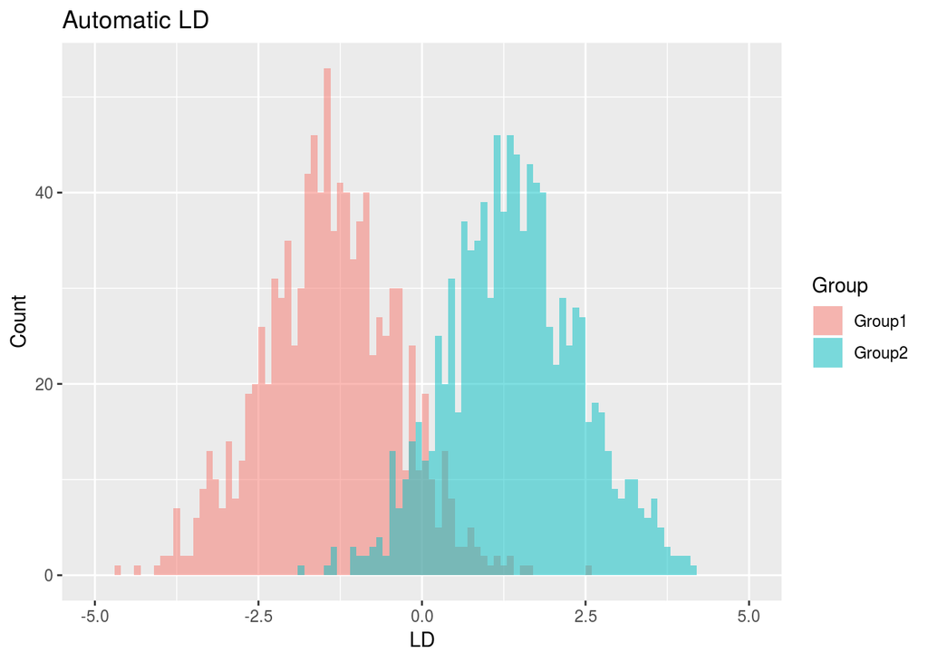

```r
hist_grp(data.frame(LD=prediction$x[, 1], Group=observations$Group), "LD") +
  ggtitle("Automatic LD")
```

We get essentially the same prediction output here as we got with the handwaving argument about the Meas3 versus Meas2 diagonal above:

```r
confusion <- as.data.frame(table(observations$Group, prediction$class))
colnames(confusion) <- c("Group", "Prediction", "Freq")
confusion$MyFreq <- my_confusion$Freq
kable_styling(kable(confusion), full_width = FALSE)
```

| Group | Prediction | Freq | MyFreq |
| --- | --- | --- | --- |
| Group1 | Group1 | 920 | 923 |
| Group2 | Group1 | 81 | 79 |
| Group1 | Group2 | 80 | 77 |
| Group2 | Group2 | 919 | 921 |

(There’s some slight variation in these results since `lds$scaling` takes into account the bit of random variation in this example and doesn’t point perfectly along the diagonal.)

# LDA Case 2 - Scaled Values

That first case had measurements that were all normalized already. What if the input values are much bigger?

```r
case2 <- run_lda(within(list(), {
  scaler <- 1000
  observations[,1:3] <- observations[,1:3]*scaler
}))

scaler_compare <- cbind.data.frame(lds$scaling, case2$lds$scaling, case2$lds$scaling*case2$scaler)
colnames(scaler_compare) <- c("LD1", "LD1Big", "LD1BigNorm")
kable_styling(kable(scaler_compare, digits=5), full_width = FALSE)
```

|  | LD1 | LD1Big | LD1BigNorm |
| --- | --- | --- | --- |
| Meas1 | 0.01925 | 0.00002 | 0.01925 |
| Meas2 | 1.02518 | 0.00103 | 1.02518 |
| Meas3 | -0.98111 | -0.00098 | -0.98111 |

The scaling vector normalizes the values by shrinking them back down to unit standard deviation per measurement, so the final linear discriminant values per observation are still on the same scale as before.

What about a case where each measurement has a *different* standard deviation?

```r
case2_stretch <- run_lda(within(list(), {
  scalers <- c(1, 10, 1000)
  observations[, 1:3] <- t(apply(observations[, 1:3], 1, function(x) x*scalers))
}))

scaler_compare <- cbind.data.frame(LD1 = lds$scaling[, 1],
                                   LD1Stretch = case2_stretch$lds$scaling[, 1],
                                   LD1StretchNorm = case2_stretch$lds$scaling[, 1]*case2_stretch$scalers)
kable_styling(kable(scaler_compare, digits=5), full_width = FALSE)
```

|  | LD1 | LD1Stretch | LD1StretchNorm |
| --- | --- | --- | --- |
| Meas1 | 0.01925 | 0.01925 | 0.01925 |
| Meas2 | 1.02518 | 0.10252 | 1.02518 |
| Meas3 | -0.98111 | -0.00098 | -0.98111 |

Both measurements still give the same amount of separation between the groups, so we know we still want to give them equal weight in determining LD1 in a sense. But the numbers are 100 times larger for Meas3 versus Meas2, and a value of 10 along the Meas2 axis is “worth” as much as 1000 along the Meas3 axis. Accordingly, LDA uses a far smaller scaling multiplier for Meas 3 here.

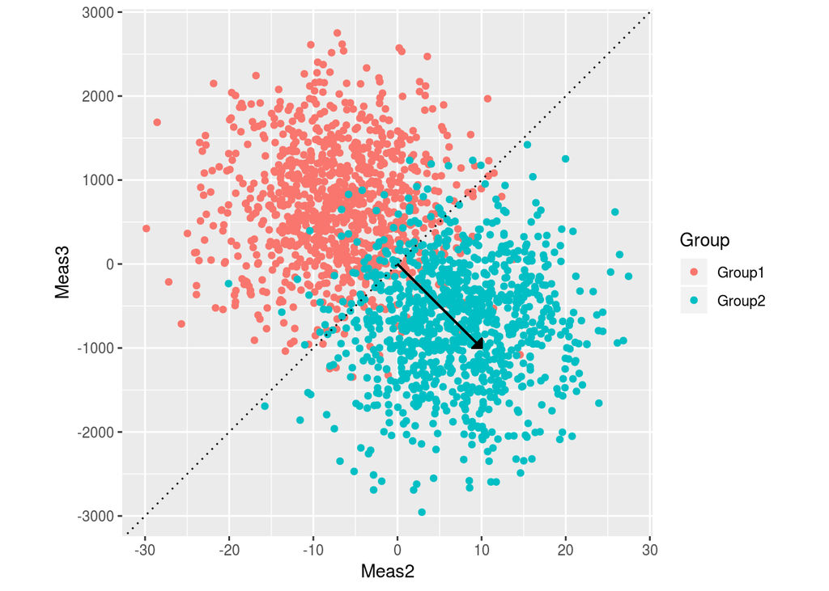

```r
with(case2_stretch, {
  scatter_grp(observations, "Meas2", "Meas3", ratio = scalers[2]/scalers[3]) +
  geom_abline(intercept = 0,
              slope = scalers[3]/scalers[2],
              linetype="dotted") +
  geom_segment(x = 0, y = 0, xend = 10, yend = -1000,
               arrow = arrow(angle = 45,
                             length = unit(0.2, "cm"),
                             type="closed"))
})
```

Accordingly, we still get the same distribution along LD1, since the separation is still essentially the same.

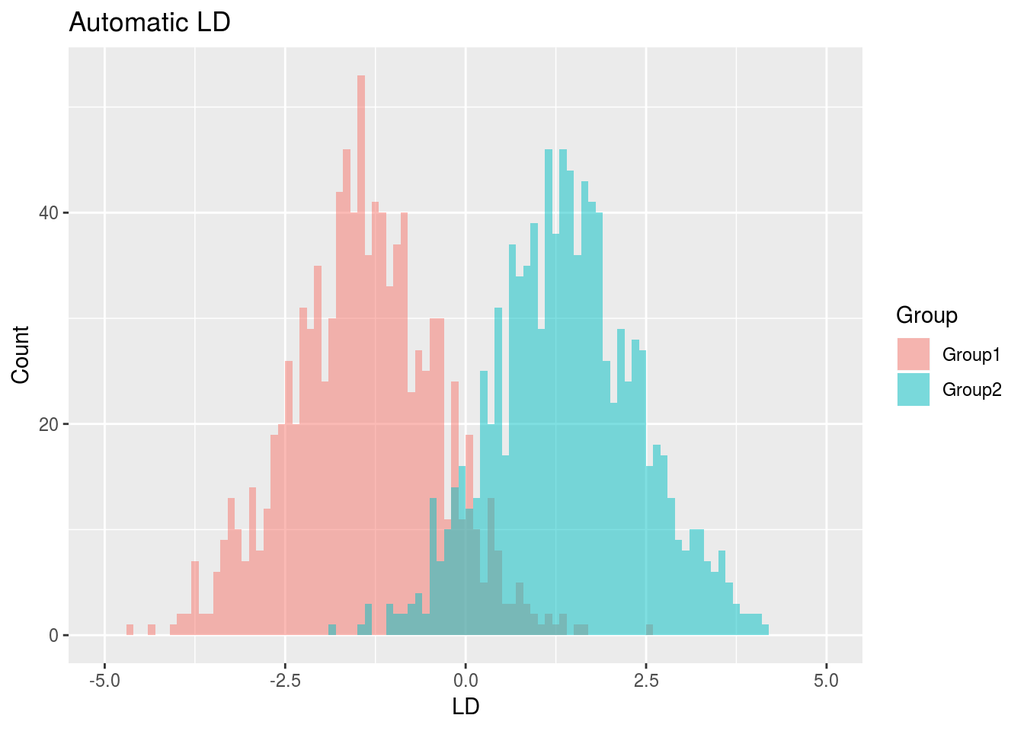

```r
with(case2_stretch, {
  hist_grp(data.frame(LD=prediction$x[, 1], Group=observations$Group), "LD") +
  ggtitle("Automatic LD")
})
```

If we take the scaling multipliers as-is, Meas2 looks much more significant than Meas3, but we know both are about equally informative; it only worked out that way here because the spread of Meas3 values was very different than that of Meas2. The first case was a simple one where all the measurements had similar properties from the start. **In the general case we need to take the spread of the values along each measurement into account to be able to compare these scaling multipliers side-by-side.** The easiest way to make this an apples-to-apples comparison is to just scale the input to standard deviation of one for each measurement.

# LDA Case 3 - An Offset from the Origin

What if the input measurements *aren’t* centered on the origin? For example if the measurements have means at 20, 40, and 60.

```r
case3 <- run_lda(within(list(), {
  shift <- (1:3)*20
  for (i in 1:3) {
   observations[, i] <- observations[, i] + shift[i]
  }
  rm(i)
}))
```

The LD vector values are the same as before, and the prediction works out as expected.

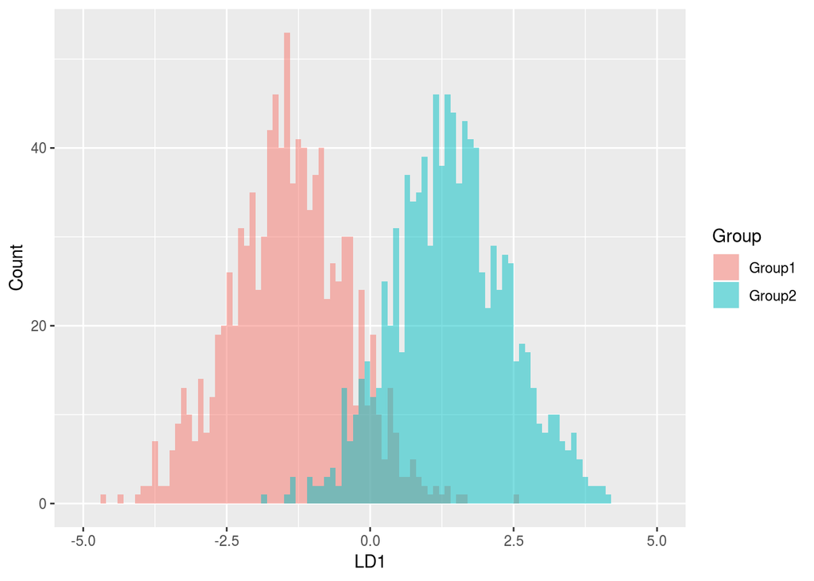

```r
p3 <- predict(case3$lds)
c3ld <- data.frame(p3$x, Group=observations$Group)
hist_grp(c3ld, "LD1")
```

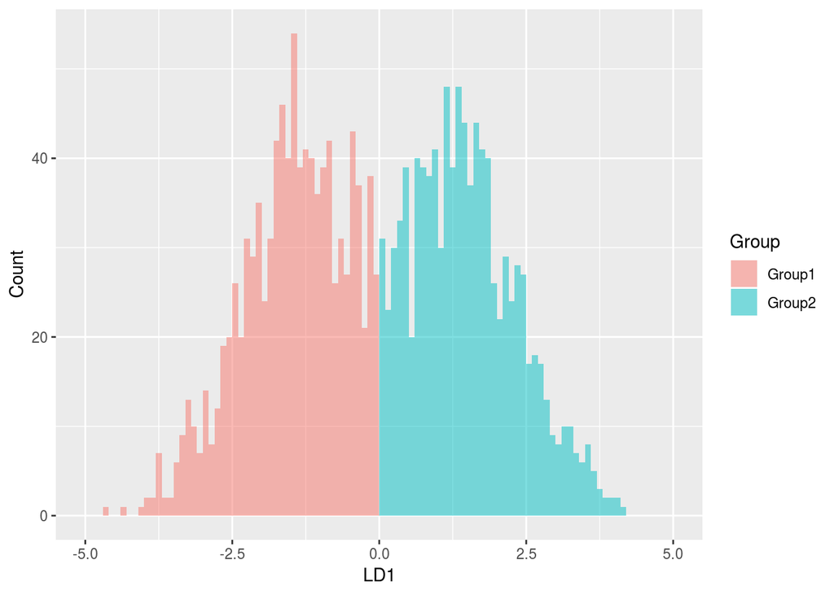

```r
c3ld_predicted <- data.frame(p3$x, Group=p3$class)
hist_grp(c3ld_predicted, "LD1")
```

If we did it manually, but ignoring the offset:

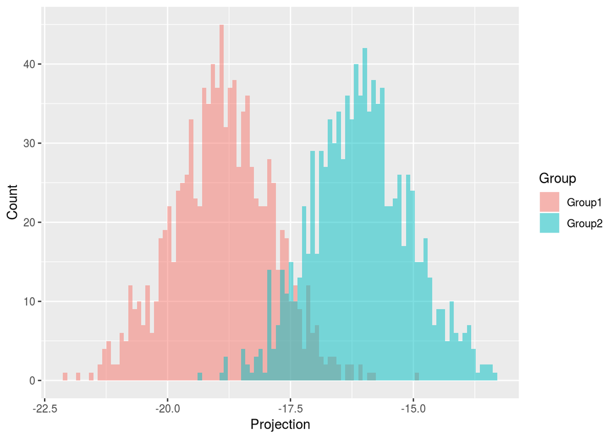

```r
case3 <- within(case3, {
  projections <- apply(observations[, 1:3], 1, dotprod, y = lds$scaling[, 1])
  projections <- data.frame(Projection = projections,
                          Group = observations$Group)
})

hist_grp(case3$projections, "Projection", breaks = NULL, bins = 100)
```

Or, with centering included:

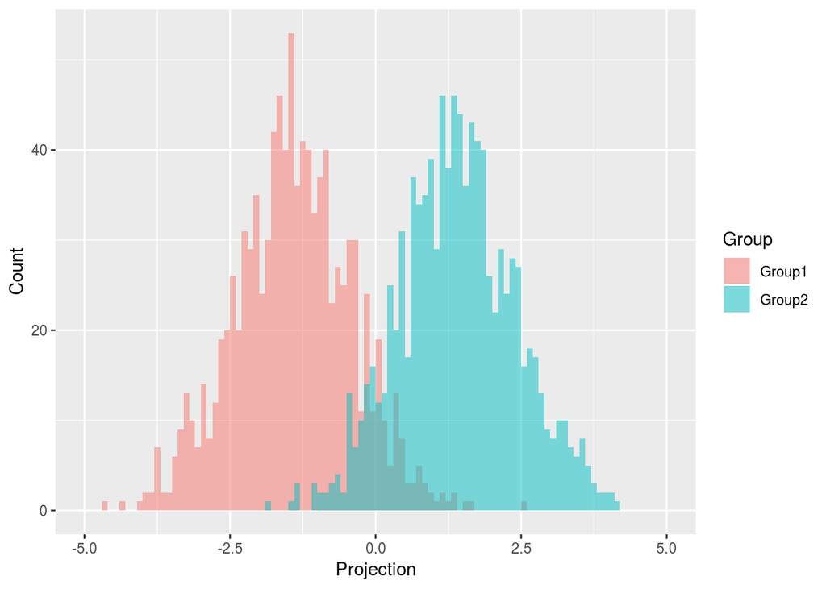

```r
case3 <- within(case3, {
  center <- colMeans(observations[, 1:3])
  projections <- apply(observations[, 1:3], 1, function(row) {
    dotprod(x = row - center, y = lds$scaling[, 1])
  })
  projections <- data.frame(Projection = projections,
                          Group = observations$Group)
})

hist_grp(case3$projections, "Projection")
```

`MASS:::predict.lda` makes calls to `scale` that center by mean, but do not scale, so this makes sense.

# LDA Case 4 - Degenerate Input

What if one or more of the measurements are not just uninformative but completely useless?

```r
case4 <- run_lda(within(list(), {
  observations[, "Meas1"] <- 0 # The first Measurment has no variation at all
}))
```

```
## Error in lda.default(x, grouping, ...): variable 1 appears to be constant within groups
```

Whoops, it refuses to run. (“The function tries hard to detect if the within-class covariance matrix is singular. If any variable has within-group variance less than tol^2 it will stop and report the variable as constant. This could result from poor scaling of the problem, but is more likely to result from constant variables.”)

# LDA Case 5 - An Offset Midpoint Between Groups

Even though the observations are centered automatically, what if the best point of separation between groups is not the origin? That is, with only one discriminant, what if the prediction is doing something other than checking for a positive/negative value?

Here we’ll slice the data strictly along that diagonal from the first case, and also shift its location by 1.0 along LD1.

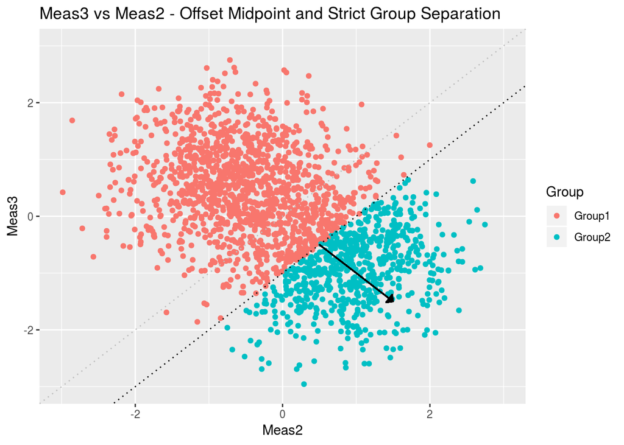

```r
case5 <- run_lda(within(list(), {
  # Shift the dividing line along LD1 a bit, but the measurement values remain
  # the same.
  observations$Group <- factor(ifelse(with(observations, Meas3 - Meas2 > -1),
                               "Group1",
                               "Group2"), levels = levels(observations$Group))
}))

with(case5, scatter_grp(observations, x = "Meas2", y = "Meas3")) +
  geom_abline(intercept = 0,
              slope = 1,
              linetype="dotted",
               color = "gray") +
  geom_abline(intercept = -1,
              slope = 1,
              linetype="dotted") +
  geom_segment(x = 0.5, y = -0.5, xend = 1.5, yend = -1.5,
               arrow = arrow(angle = 45,
                             length = unit(0.2, "cm"),
                             type="closed")) +
  coord_cartesian(xlim = c(-3, 3), ylim = c(-3, 3)) +
  ggtitle("Meas3 vs Meas2 - Offset Midpoint and Strict Group Separation")
```

There, that should be easy to split. But, it actually classifies the last few Group1 cases as Group2. (Why? Because of the strange distribution in group membership? Investigate more.)

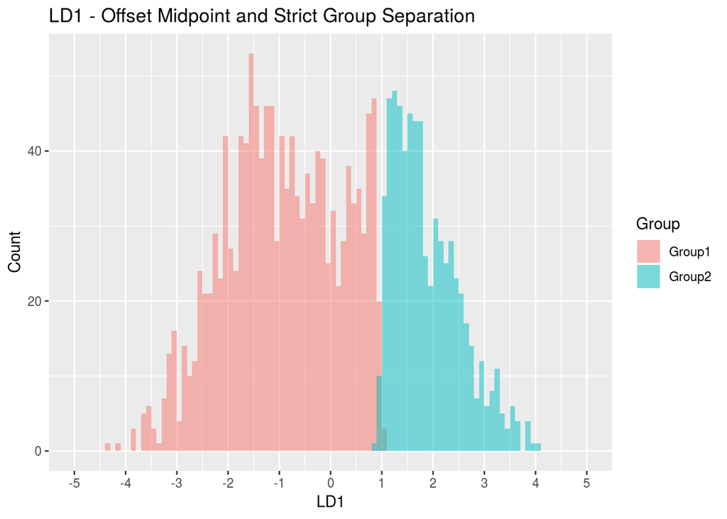

```r
with(case5, hist_grp(observations, "LD1")) +
  scale_x_continuous(breaks = seq(-5, 5, 1)) +
  ggtitle("LD1 - Offset Midpoint and Strict Group Separation")
```

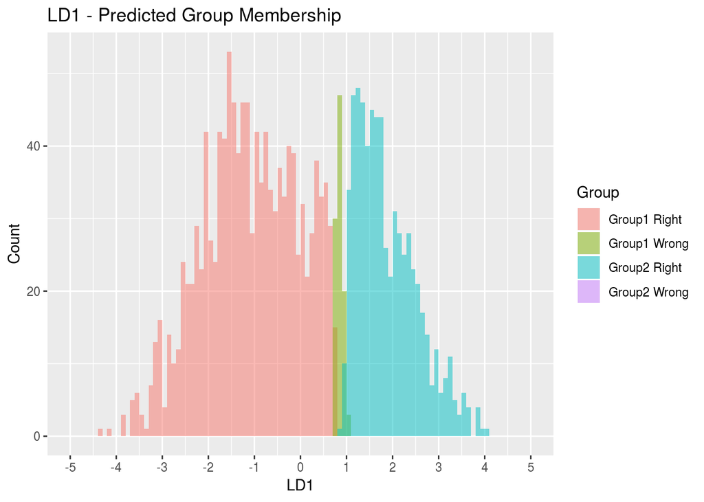

```r
case5$observations$GroupWrong <- with(case5$observations,
                                      factor(paste(Group, ifelse(Wrong, "Wrong", "Right")),
                                             levels = c("Group1 Right",
                                                        "Group1 Wrong",
                                                        "Group2 Right",
                                                        "Group2 Wrong")))
with(case5, hist_grp(observations, "LD1", grp = "GroupWrong")) +
  scale_fill_discrete(drop=FALSE) +
  scale_x_continuous(breaks = seq(-5, 5, 1)) +
  ggtitle("LD1 - Predicted Group Membership")
```

TODO explain more what predict() can do here; with that function, we don’t have to worry about where these breakpoints are.

# LDA Case 6 - Categorical Measurements

What happens with categorical (factor) variables? The geometric view doesn’t apply without some rearranging on the input.

```r
# Adding a column for a categorical measurement
case6 <- run_lda(within(list(), {
  # A factor with four levels, and varying proportions between them.
  N <- 4
  observations$Meas4 <- sample(1:N, # N distinct values
                               nrow(observations), # total observations
                               prob = 1:N, # increasing probability (it'll normalize automatically)
                               replace = TRUE) # allow repeats
  observations$Meas4 <-  as.factor(observations$Meas4)
  levels(observations$Meas4) <- LETTERS[1:N]
}))

# Alternatively, what if we have separate columns for each possible category
# above, where 1 means present and 0 means absent (and the first category is
# missing but implied by all-zero on the rest)?
case6_wide <- run_lda(within(list(), {
  cols <- do.call(cbind.data.frame,
                  lapply(levels(case6$observations$Meas4)[-1],
                         function(lvl) (case6$observations$Meas4 == lvl) + 0))
  colnames(cols) <- paste0("Meas4", levels(case6$observations$Meas4)[-1])
  observations <- cbind(observations, cols)
}))
```

It looks like it just splits the single factor with N levels into N-1 separate variables, each with one for present and zero for absent (so the means correspond to the proportions). It would only need N-1 since all zero implies the first level. That’s a guess from the return value, but it gives identical output when given the separate columns of binary input (`case6_wide` above), so I think that makes a strong case.

```r
k <- kable(with(case6, lds$means[, paste0("Meas4", levels(observations$Meas4)[-1])]))
kable_styling(k, full_width = FALSE)
```

|  | Meas4B | Meas4C | Meas4D |
| --- | --- | --- | --- |
| Group1 | 0.194 | 0.285 | 0.418 |
| Group2 | 0.199 | 0.312 | 0.399 |

```r
k <- kable(with(case6, table(observations$Meas4)/nrow(observations)))
kable_styling(k, full_width = FALSE)
```

| Var1 | Freq |
| --- | --- |
| A | 0.0965 |
| B | 0.1965 |
| C | 0.2985 |
| D | 0.4085 |

When giving a factor as a column versus giving N-1 separate columns for the different factor levels:

```r
case6_compare <- cbind.data.frame(case6$lds$scaling,
                                  case6_wide$lds$scaling)
colnames(case6_compare) <- c("LD1_Factor", "LD1_Boolean")
kable_styling(kable(case6_compare, digits = 3), full_width = FALSE)
```

|  | LD1_Factor | LD1_Boolean |
| --- | --- | --- |
| Meas1 | 0.019 | 0.019 |
| Meas2 | 1.027 | 1.027 |
| Meas3 | -0.981 | -0.981 |
| Meas4B | -0.071 | -0.071 |
| Meas4C | 0.016 | 0.016 |
| Meas4D | -0.110 | -0.110 |

# LDA Case 7 - More Groups

The prediction gets more complicated with more than two groups, since there are multiple “dividing lines” and also more than one linear discriminant.

TODO fill this in.